# Reproducible Research: Peer Assessment 1

```r
library(tidyverse)
```

## Loading and preprocessing the data

We unzip the archive, load a CSV file and have a look at the data.

```r
unzip("./activity.zip")
activity <- read_csv("./activity.csv")
glimpse(activity)
```

```
## Rows: 17,568
## Columns: 3
## $ steps    <dbl> NA, NA, NA, NA, NA, NA, NA, NA, NA, NA, NA, NA, NA, NA, NA, …
## $ date     <date> 2012-10-01, 2012-10-01, 2012-10-01, 2012-10-01, 2012-10-01,…
## $ interval <dbl> 0, 5, 10, 15, 20, 25, 30, 35, 40, 45, 50, 55, 100, 105, 110,…
```

```r
summary(activity)
```

```
##      steps             date               interval
##  Min.   :  0.00   Min.   :2012-10-01   Min.   :   0.0
##  1st Qu.:  0.00   1st Qu.:2012-10-16   1st Qu.: 588.8
##  Median :  0.00   Median :2012-10-31   Median :1177.5
##  Mean   : 37.38   Mean   :2012-10-31   Mean   :1177.5
##  3rd Qu.: 12.00   3rd Qu.:2012-11-15   3rd Qu.:1766.2
##  Max.   :806.00   Max.   :2012-11-30   Max.   :2355.0
##  NA's   :2304
```

## What is mean total number of steps taken per day?

First summary statistics of steps per each day are produced:

```r
activity_per_day <- activity %>%
  group_by(date) %>%
  summarise(total_steps = sum(steps, na.rm = TRUE),
            mean = mean(steps, na.rm = TRUE))
head(activity_per_day)
```

```
## # A tibble: 6 x 3
##   date       total_steps    mean
##   <date>           <dbl>   <dbl>
## 1 2012-10-01           0 NaN
## 2 2012-10-02         126   0.438
## 3 2012-10-03       11352  39.4
## 4 2012-10-04       12116  42.1
## 5 2012-10-05       13294  46.2
## 6 2012-10-06       15420  53.5
```

Histogram of total amount of steps taken per day:

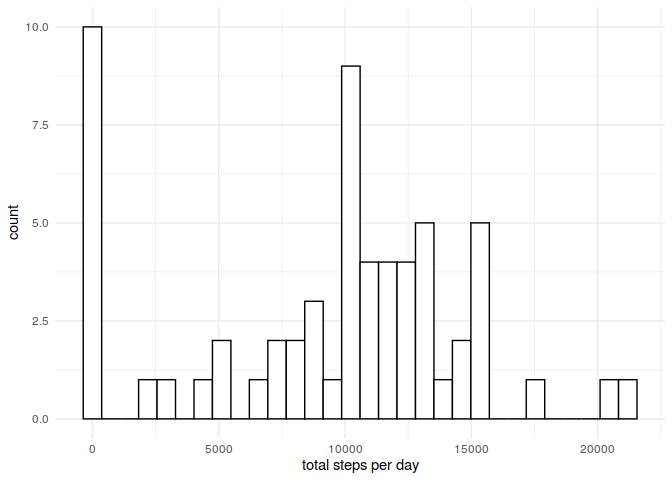

```r
ggplot(activity_per_day, aes(x = total_steps)) +
  geom_histogram(fill = "white", color = "black") +
  theme_minimal() +
  xlab("total steps per day")
```

We see that first *peak* is at or around zero (caused mainly by the missing values), otherwise the distribution looks quite normal with a peak around 10.000 steps per day.

Lets confirm this with summary statistics:

```r
activity_per_day %>%
  summarise(mean = mean(total_steps, na.rm = TRUE),
            median = median(total_steps, na.rm = TRUE))
```

```
## # A tibble: 1 x 2
##    mean median
##   <dbl>  <dbl>
## 1 9354.  10395
```

## What is the average daily activity pattern?

Now we look at the activity pattern during the average day.

```r
activity_per_interval <- activity %>%
  group_by(interval) %>%
  summarise(steps = mean(steps, na.rm = TRUE))
```

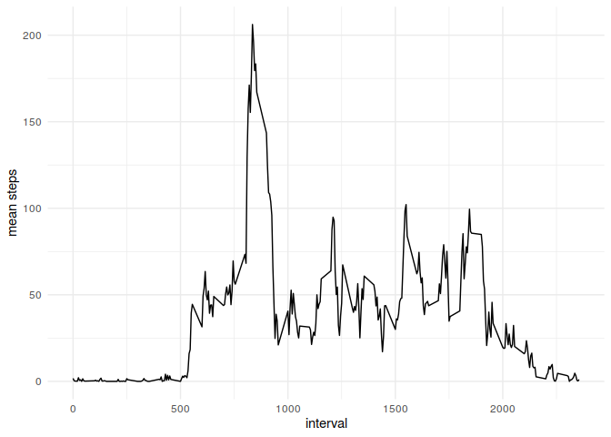

```r
g <- activity_per_interval %>%
  ggplot(aes(x = interval, y = steps)) +
  geom_line() +
  theme_minimal() +
  ylab("mean steps")

g
```

To highlight the average daily pattern we can add individual datapoints in the background and use a smooth line:

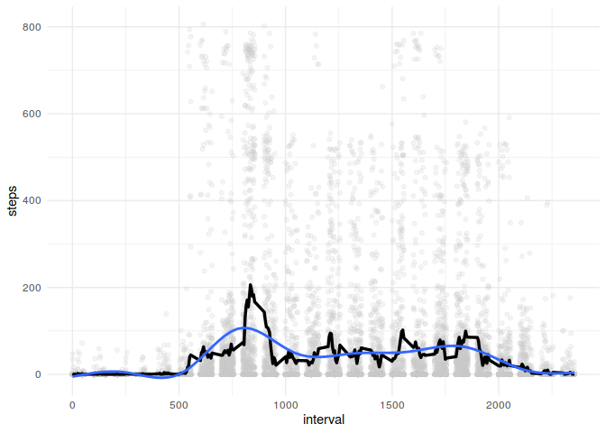

```r
activity %>%
  ggplot(aes(x = interval, y = steps)) +
  geom_point(alpha = 0.2, color = "gray80") +
  geom_line(data = activity_per_interval, size = 1.2, color = "black") +
  geom_smooth(se = FALSE) +
  theme_minimal() +
  ylab("steps")
```

We can see that on average, the highest activity is in the interval between 500-1000 with a second small peak in an interval 1500-2000.

Maximum number of steps (206.1698113) across all days is in an iterval 835.

```r
activity_per_interval %>%
  arrange(desc(steps)) %>%
  head(1)
```

```
## # A tibble: 1 x 2
##   interval steps
##      <dbl> <dbl>
## 1      835  206.
```

## Imputing missing values

There are 2304 rows with missing values for `steps` variable. That is around 13% of missing values.

```r
sum(is.na(activity$steps))
```

```
## [1] 2304
```

```r
# round(mean(is.na(activity$steps))*100)
```

The missing values for steps are imputed using a mean value of that day where possible, for days were all the values are missing (thus it is impossible to get a mean), the overall mean is used.

```r
# mean steps for the whole dataset
mean_steps_all <- activity %>%
  summarise(mean = mean(steps, na.rm = TRUE)) %>%
  pull(mean)

# mean steps for each day
mean_steps_day <- activity_per_day %>%
  select(date, mean) %>%
  mutate(mean = if_else(is.na(mean), mean_steps_all, mean))

# imputing missing values
activity_imputed <- activity %>%
  mutate(missing = if_else(is.na(steps), date, as.Date(NA))) %>%
  left_join(mean_steps_day, by = c("missing" = "date")) %>%
  transmute(date, interval,
            steps = if_else(is.na(steps), mean, steps))

head(activity_imputed)
```

```
## # A tibble: 6 x 3
##   date       interval steps
##   <date>        <dbl> <dbl>
## 1 2012-10-01        0  37.4
## 2 2012-10-01        5  37.4
## 3 2012-10-01       10  37.4
## 4 2012-10-01       15  37.4
## 5 2012-10-01       20  37.4
## 6 2012-10-01       25  37.4
```

Dataset with imputed values gives these results:

```r
activity_imputed_per_day <- activity_imputed %>%
  group_by(date) %>%
  summarise(total_steps = sum(steps))
```

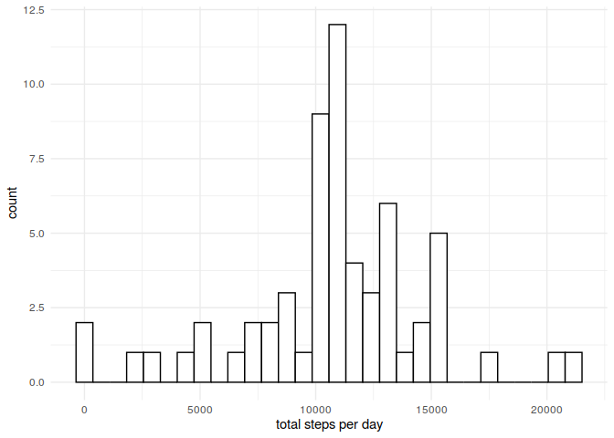

```r
activity_imputed_per_day %>%
  ggplot(aes(x = total_steps)) +
  geom_histogram(fill = "white", color = "black") +
  theme_minimal() +
  xlab("total steps per day")
```

```r
activity_imputed_per_day %>%
  summarise(mean = mean(total_steps),
            median = median(total_steps))
```

```
## # A tibble: 1 x 2
##     mean median
##    <dbl>  <dbl>
## 1 10766. 10766.
```

In the comparison with the original histogram and summary statistics we see that imputing missing values with given means articulates the peak in the histogram and moves both mean and median to the center of the distribution on the same value.

The chosen approach is definitely not the best but the overall trends seem to stay more less the same as in the original dataset. The midpoint is still around 10.000 steps but the results obtained from working with this dataset will tend to show higher activity (step count) than the original dataset because both mean and median of the imputed values are higher than the original.

## Are there differences in activity patterns between weekdays and weekends?

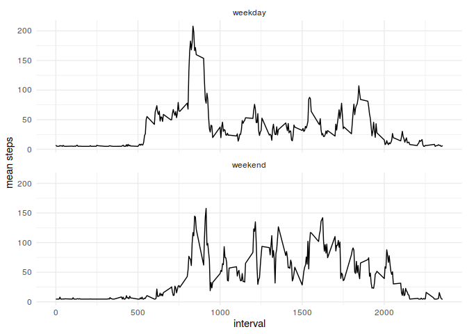

```r
activity_imputed %>%
  mutate(weekday = weekdays(date),
         weekpart = if_else(weekday %in% c("Sunday", "Saturday"), "weekend", "weekday"),
         weekpart = as.factor(weekpart)) %>%
  select(-weekday, -date) %>%
  group_by(weekpart, interval) %>%
  summarise(mean_steps = mean(steps)) %>%
  ggplot(aes(x = interval, y = mean_steps)) +
  geom_line() +
  facet_wrap(vars(weekpart), nrow = 2) +
  ylab("mean steps") +
  theme_minimal()
```

We can see that on the weekdays the curve starts to go up slightly earlier and after the interval of 1000 is not very *wiggly*, on the other hand, during the weekends, there are many changes throughout the day, meaning the person does more steps.